# INTRODUCTION TO DATA VISUALIZATION WITH GGPLOT2

### 1.5 ggplot2 layers

The grammar of graphics is implemented in R using the **ggplot2** package. There are two key functions that **ggplot2** serves: - Layer grammatical elements: construct plots by layering grammatical elements on top of each other. - Aesthetic mapping: bridge the link between data and its visual interpretation.

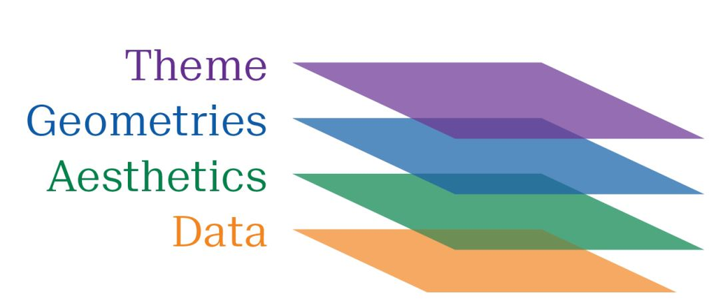

To illustrate this we will use the classical **iris** dataset collected by Edgar Aderson in the 1930s. The dataset contains information on three iris species: setosa, versicolor, and virginica. Four measurements were taken from each plant: the petal length and width and the sepal length and width. There are 50 specimens of each species.

```r
head(iris)
```

```
##   Sepal.Length Sepal.Width Petal.Length Petal.Width Species
## 1          5.1         3.5          1.4         0.2  setosa
## 2          4.9         3.0          1.4         0.2  setosa
## 3          4.7         3.2          1.3         0.2  setosa
## 4          4.6         3.1          1.5         0.2  setosa
## 5          5.0         3.6          1.4         0.2  setosa
## 6          5.4         3.9          1.7         0.4  setosa
```

Make a scatter plot with `Sepal.Length` mapped to `x` and `Sepal.width` to `y` aesthetics:

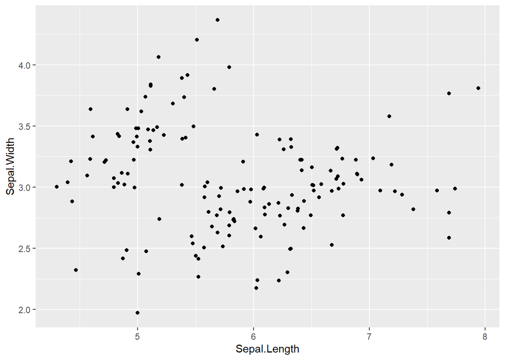

```r
ggplot(iris, aes(Sepal.Length, Sepal.Width)) +
  geom_jitter()
```

With three essential layers, there are enough instructions to make a basic scatter plot. It looks pretty rough. To get a more meaningful and cleaner visualization, we will add the *theme* layer. This controls all the non-data in on the plot, which allows us to get a nice looking, meaningful and publication-quality plot directly in R.

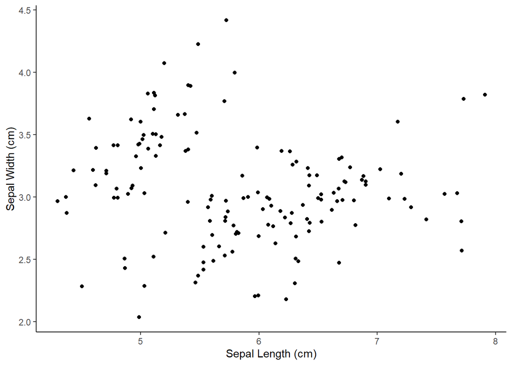

```r
ggplot(iris, aes(Sepal.Length, Sepal.Width)) +
  geom_jitter() +
  labs(x = "Sepal Length (cm)", y = "Sepal Width (cm)") +
  theme_classic()
```